# Chapter 10: Confidence Intervals

# Scene 1

**Prompt:** Explore train data from the **gov.1005.data** with your partner and try to figure out what it means. Recall the syllabus assignment: “Causal effect of intergroup contact on exclusionary attitudes” by Ryan Enos. PNAS March 11, 2014 111 (10) 3699-3704. [link](https://www.pnas.org/content/pnas/111/10/3699.full.pdf%20). You read it, right? Read the abstract at least! Can you find any “interesting” observations? Make a plot! Which variables are worth looking at? It may be necessary to help students with the key variables. `treatment` has two levels, `Treated` and `Control`. The Treated have two Spanish-speakers have a conversation on their commuter train platform. The Control do not. Both before and after the treatment, everyone answers three questions about immigration. The answer for each question is codes from 1 (strongly disagree) through 5 (strongly agree). So, the most “conservative” starting attitude (`att_start`) before the treatment would be 15.

```r
# these are ways to get to know the data
glimpse(train)
```

```
## Observations: 115
## Variables: 9
## $ male       <int> 0, 0, 1, 1, 1, 0, 0, 1, 0, 1, 0, 1, 1, 1, 1, 0, 0, 1, 0, 0…
## $ liberal    <int> 0, 0, 1, 0, 1, 0, 0, 0, 0, 0, 0, 0, 0, 1, 1, 1, 0, 0, 1, 0…
## $ republican <int> 0, 1, 0, 0, 0, 0, 1, 0, 0, 1, 0, 0, 1, 0, 0, 0, 0, 1, 0, 1…
## $ age        <dbl> 31, 34, 63, 45, 55, 37, 53, 36, 54, 42, 33, 50, 24, 40, 53…
## $ income     <dbl> 135000, 105000, 135000, 300000, 135000, 87500, 87500, 1350…
## $ treatment  <fct> Treated, Treated, Treated, Treated, Control, Treated, Cont…
## $ att_start  <dbl> 11, 9, 3, 11, 8, 13, 13, 10, 12, 9, 10, 11, 13, 6, 8, 13, …
## $ att_end    <dbl> 11, 10, 5, 11, 5, 13, 13, 11, 12, 10, 9, 9, 13, 7, 8, 13, …
## $ att_chg    <dbl> 0, 1, 2, 0, -3, 0, 0, 1, 0, 1, -1, -2, 0, 1, 0, 0, 1, 0, 0…
```

```r
summary(train)
```

```
##       male           liberal         republican          age
##  Min.   :0.0000   Min.   :0.0000   Min.   :0.0000   Min.   :20.00
##  1st Qu.:0.0000   1st Qu.:0.0000   1st Qu.:0.0000   1st Qu.:33.00
##  Median :1.0000   Median :0.0000   Median :0.0000   Median :43.00
##  Mean   :0.5565   Mean   :0.4435   Mean   :0.1652   Mean   :42.37
##  3rd Qu.:1.0000   3rd Qu.:1.0000   3rd Qu.:0.0000   3rd Qu.:52.00
##  Max.   :1.0000   Max.   :1.0000   Max.   :1.0000   Max.   :68.00
##      income         treatment    att_start         att_end
##  Min.   : 23500   Treated:51   Min.   : 3.000   Min.   : 3.000
##  1st Qu.: 87500   Control:64   1st Qu.: 7.000   1st Qu.: 7.000
##  Median :135000                Median : 9.000   Median : 9.000
##  Mean   :141813                Mean   : 9.191   Mean   : 9.139
##  3rd Qu.:135000                3rd Qu.:11.000   3rd Qu.:11.000
##  Max.   :300000                Max.   :15.000   Max.   :15.000
##     att_chg
##  Min.   :-4.00000
##  1st Qu.:-1.00000
##  Median : 0.00000
##  Mean   :-0.05217
##  3rd Qu.: 1.00000
##  Max.   : 6.00000
```

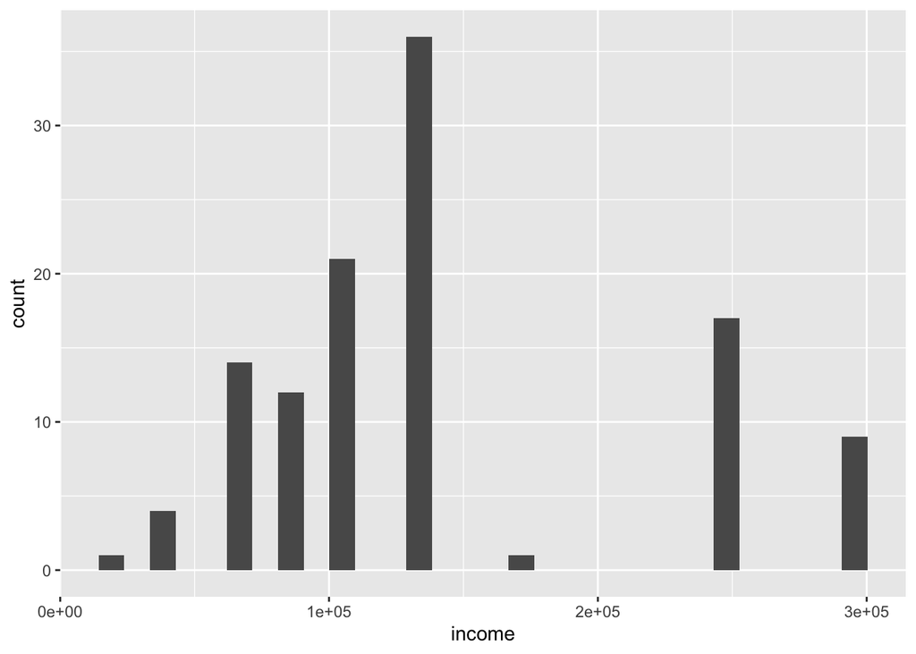

```r
train %>%
  ggplot(aes(x = income)) + geom_histogram()
```

# Scene 2

**Prompt:** What is the average income of the commuters? How sure can we be of that number? If we were to survey another 115 commuters, what would their average income be? How does this connect to the difference between the harpoon and the net in the book? Don’t know? Look it up!

```r
# Either one of these work, but the second version is a bit better because it is more flexible

mean(train$income)
```

```
## [1] 141813
```

```r
train %>%
  summarize(average_income = mean(income))
```

```
## # A tibble: 1 x 1
##   average_income
##            <dbl>
## 1        141813.
```

# Scene 3

**Prompt:** Create a bootstrap sample of a 1,000 replications of the mean income of the commuters, where each replication draws the appropriate number, with replacement, from the original data.

```r
# Use rep sample n. The total number of people both treated and not treated is 115. We then group by replicate. From there we can use the summarize function to find the mean income for each replicate.

train %>%
rep_sample_n(115, replace = TRUE, reps = 1000) %>%
  group_by(replicate) %>%
  summarize(mean_income = mean(income))
```

```
## # A tibble: 1,000 x 2
##    replicate mean_income
##        <int>       <dbl>
##  1         1     134030.
##  2         2     132043.
##  3         3     132913.
##  4         4     138065.
##  5         5     135891.
##  6         6     161161.
##  7         7     142204.
##  8         8     148922.
##  9         9     135539.
## 10        10     142087.
## # … with 990 more rows
```

# Scene 4

**Prompt:** Using the bootstrap sample you create, calculate the 50% confidence interval (using the percentile method) of the true mean income of commuters. What is the meaning of this interval? What does it tell us about the world that we did not know before? Is that the same thing as thinking that there is a 50% chance that, if we were to draw a new commuter at random, that her income would fall within that range? Why or why not? What if, instead of looking at all commuters in the sample, we just looked at the Treated. That is easy to do with a single `filter()`. But would the interpretation of the confidence interval be the same or different?

```r
# Call in what we had done earlier. We need the averages for each replicate
train %>%
rep_sample_n(115, replace = TRUE, reps = 1000) %>%
  group_by(replicate) %>%
  summarize(mean_income = mean(income)) %>%
# we need to pull out the variable we're interested in
   pull(mean_income) %>%
# we are interested in the 50% ci Do the quantile method to pull desired values
  quantile(c(0.25,0.75))
```

```
##      25%      75%
## 137248.9 146613.0
```

# Scene 5

**Prompt:** Calculate the difference between the income of treated and control commuters in our sample. We need to subtract the Control average from the Treated average. To do that, having them on the same row is convenient. Recall the `pivot_*` functions. `everything()` is also a cool trick for organizing the order of the variables in a tibble. I like to put the key variable, which would be the income difference in this case, first.

```r
train %>%
# First we group by treatment vs not treated
  group_by(treatment) %>%
# find the average income for each group
  summarize(mean_income = mean(income)) %>%
# Pivot wider but not sure why
  pivot_wider(
    names_from= treatment,
    values_from = mean_income
  ) %>%
  # Make a new column to make it obvious what is the difference
  mutate(diff = Treated - Control)
```

```
## # A tibble: 1 x 3
##   Treated Control    diff
##     <dbl>   <dbl>   <dbl>
## 1 132892. 148922. -16030.
```

# Scene 7

**Prompt:** Calculate a 95% confidence interval for the difference between the mean income of treated and control commuters in our sample. Provide a Bayesian and Frequentist interpretation of this interval.

```r
train %>%
rep_sample_n(115, replace = TRUE, reps = 1000) %>%
  group_by(treatment, replicate) %>%
  summarize(mean_income = mean(income)) %>%
  pivot_wider(
    names_from= treatment,
    values_from = mean_income
  ) %>%
  mutate(diff = Treated - Control) %>%
# pull the diff column because these are the values we're interested in
  pull(diff) %>%
  quantile(c(.025, .975))
```

```
##      2.5%     97.5%
## -41949.41  11502.33
```

# Scene 8

**Prompt:** What about the difference between att_chg of the treated and the controls? Calculate the mean difference, just as we did with income. Is this difference “large?”

# Scene 9

**Prompt:** What is the 99% confidence interval for that difference?

```r
prompt9 <- train %>%
  rep_sample_n(size = 115, replace = TRUE, reps = 1000) %>%
  group_by(treatment, replicate) %>%
  summarize(mean_att_chg = mean(att_chg)) %>%
  pivot_wider(names_from = treatment, values_from = mean_att_chg) %>%
  mutate(att_chg_difference = Treated - Control) %>%
  select(att_chg_difference, everything()) %>%
  pull(att_chg_difference) %>%
  quantile(c(0.005, 0.995))
prompt9
```

```
##      0.5%     99.5%
## 0.1376428 1.5157266
```

# Scene 10

**Prompt:** Use `lm()` to calculate the difference between att_chg of the treated and the controls?

# Scene 11

**Prompt:** Calculate the 99% confidence interval for the difference between att_chg of the treated and the controls using a bootstrap approach and `lm()`? Note that this actually uses some tricks, like `nest()` and model objects in list columns, which the book only covers in chapter 11. Never hurts to get ahead!

# Scene 12

**Prompt:** Calculate the 95% confidence interval using simple `lm()`?

# Challenge Problem

**Prompt:** We started with a cleaned up version of the data from Enos. Can you replicate that data set? Start from the Dataverse.